# EXAM in Financial Econometrics

AP-0004-XHZ

February 13-15, 2019

### Quick Look at the Plots

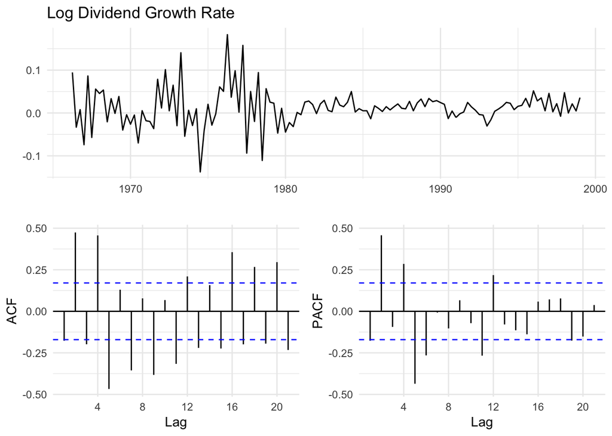

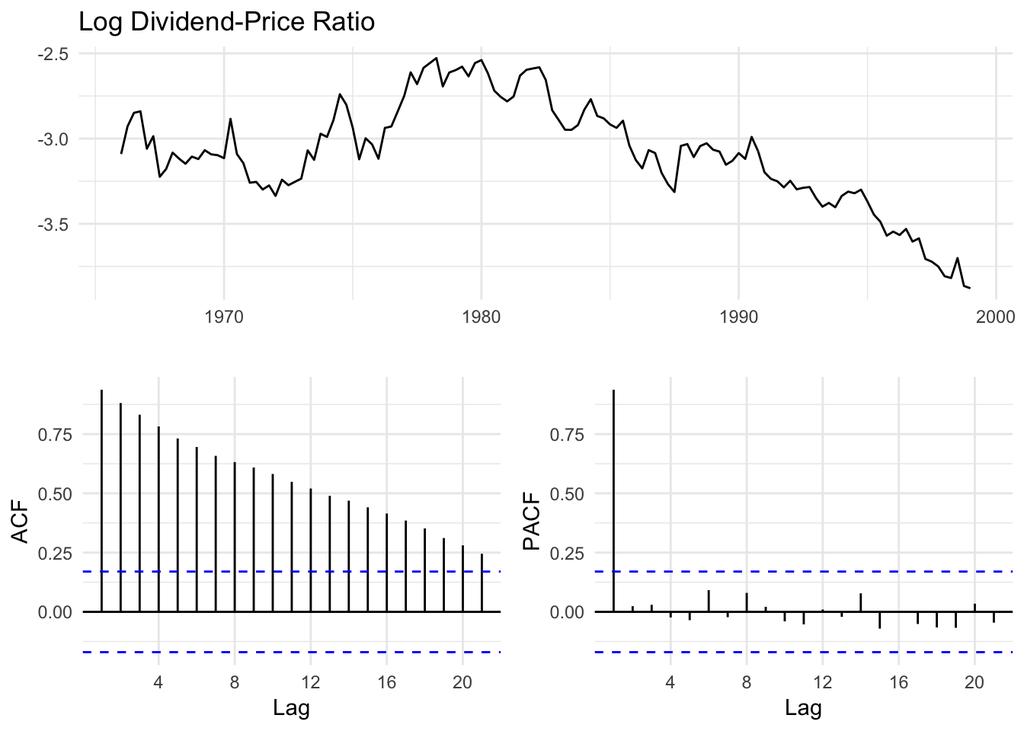

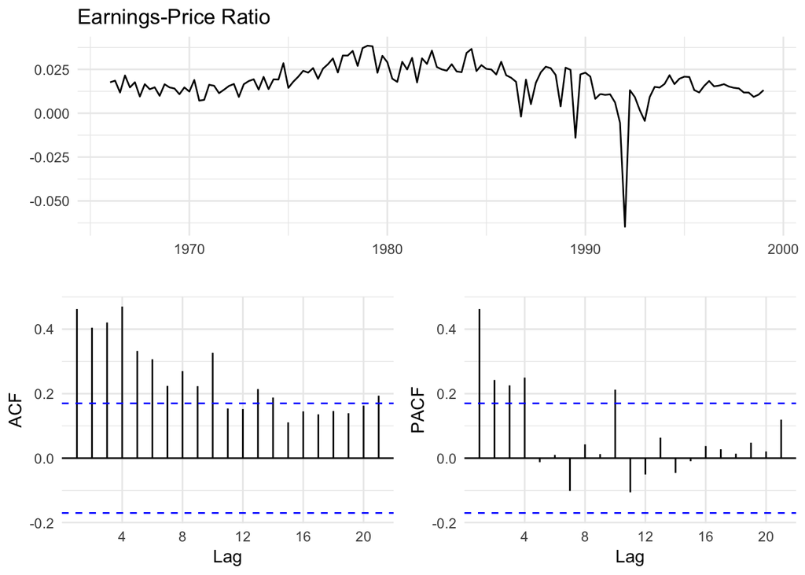

# Present-Value Relations (continued)

## Question 1

#### 1.Evaluate the long-term predictability of log dividend growth rates. In particular, compute overlapping long-term log dividend growth rates and regress them on appropriate information variables of your choice prevailing at the beginning of the corresponding period. What do you find?

In Panel B, we can also notice that the price-earnings ratio is little informative about cumulative the log dividend growth rate and, although not statistically signicantly, it is possibly negatively correlated with it. Quite to the contrary and not surprisingly, we can observe in Panel C that the log dividend-price ratio has largest R-sq (about 13 percent). In addition to this, there is also evidence of the hump-shaped response of the R-sq and t-statistic after quarter 48, after which both statistics decline for this variable. This hints in the direction for the dividend yield to be a quite good proxy for very long-run expectations concerning returns.

Long-Horizon Regressions (Dep. Var: Log Dividend Growth Rate)

| Horizon (Quarters) | Coeff. | SD | t-stat | p-value | R-sq. |
| --- | --- | --- | --- | --- | --- |
| **Panel A: Price-Dividend Ratio** |  |  |  |  |  |
| 8 | 0.3734 | 0.2178 | 1.7148 | 0.0889 | 0.0233 |
| 20 | 0.8966 | 0.2736 | 3.2771 | 0.0014 | 0.0882 |
| 40 | 0.7584 | 0.2525 | 3.0032 | 0.0034 | 0.0902 |
| 48 | 0.8522 | 0.2407 | 3.5400 | 0.0007 | 0.1312 |
| 60 | 0.9215 | 0.3776 | 2.4404 | 0.0172 | 0.0774 |
| **Panel B: Price-Earnings Ratio** |  |  |  |  |  |
| 8 | -0.0037 | 0.0147 | -0.2522 | 0.8013 | 0.0005 |
| 20 | -0.0058 | 0.0147 | -0.3954 | 0.6933 | 0.0014 |
| 40 | 0.0085 | 0.0162 | 0.5232 | 0.6021 | 0.0030 |
| 48 | -0.0063 | 0.0163 | -0.3846 | 0.7015 | 0.0018 |
| 60 | 0.0601 | 0.0727 | 0.8261 | 0.4115 | 0.0095 |
| **Panel C: Log Dividend-Price Ratio** |  |  |  |  |  |
| 8 | -8.1392 | 4.6735 | -1.7416 | 0.0841 | 0.0241 |
| 20 | -16.4679 | 5.4080 | -3.0451 | 0.0029 | 0.0771 |
| 40 | -14.4525 | 4.7598 | -3.0364 | 0.0031 | 0.0920 |
| 48 | -16.1040 | 4.5102 | -3.5706 | 0.0006 | 0.1332 |
| 60 | -18.3954 | 7.0330 | -2.6156 | 0.0109 | 0.0879 |
| **Panel D: Yield Spread** |  |  |  |  |  |
| 8 | -1.3068 | 0.3445 | -3.7930 | 0.0002 | 0.1047 |
| 20 | 0.0445 | 0.3752 | 0.1187 | 0.9057 | 0.0001 |
| 40 | -0.5483 | 0.3318 | -1.6525 | 0.1019 | 0.0291 |

## Question 1

#### Analyze the short-run dynamics by estimating a VAR(1) model for logreturns,log dividend-price ratios, earnings-price ratios as well as log dividend growth rates based on the constructed price index. Estimate the individual equations separately and interpret the estimates. Moreover, compute the correlation matrix of the residual series based on all four equations. What can you learn from these correlations?

I estimate a VAR(1) equation-by-equation, compute forecast error variance decomposition for 2 quarters ahead by iterating forward the reduced-form VAR, and show the correlation matrix. I avoid to show the estimated coefficient because I argue that it is more instructive to look at the errror variance decomposition. The two quarters ahead are an arbitrary short run of my choice. I turn to the FEVD first.

Errors in forecasting log returns are not explained by shocks occurring to other variables, as most of the error news of the log returns themselves. A similar picture emerges the log dividend growth rate and the and the earnings-price ratio. On the contrary, already one quarter ahead, only 19 percen of unpredicted changes in the log dividend-price ratio can be attributed to its own shocks. More than 57 percent is indeed due to shocks to the log returns, and to a minor extent by news in the log dividend growth rate. This relationship exacerbtes in the second quarter forecasted error variance. Hence, there does not to be much interaction among these 4 variables if one excludes the string expectational relationship between log dividend yields and log returns.

Forecast Error Variance decomposition

| Quarters Ahead | Log Returns | Log Div. Growth Rate | E/P Ratio | Log D/P Ratio |
| --- | --- | --- | --- | --- |
| **Panel A: Log Returns** |  |  |  |  |
| 1 | 100.0000 | 0.0000 | 0.0000 | 0.0000 |
| 2 | 98.9776 | 0.3424 | 0.6344 | 0.0455 |
| **Panel B: Log Dividend Growth Rate** |  |  |  |  |
| 1 | 1.4431 | 98.5569 | 0.0000 | 0.0000 |
| 2 | 1.3780 | 96.9064 | 1.6151 | 0.1006 |
| **Panel C: Earnings-Price Ratio** |  |  |  |  |
| 1 | 0.0837 | 5.0805 | 94.8357 | 0.0000 |
| 2 | 2.2227 | 4.5163 | 93.0923 | 0.1687 |
| **Panel D: Dividend-Price Ratio** |  |  |  |  |
| 1 | 57.3461 | 23.0933 | 0.0916 | 19.4690 |
| 2 | 64.2895 | 16.4729 | 0.8777 | 18.3599 |

Correlation Matrix VAR(1)

|  | Log Returns | Log Div. Growth Rate | E/P Ratio | Log D/P Ratio |
| --- | --- | --- | --- | --- |
| Log Returns | 1.0000 | 0.1201 | -0.0289 | -0.7573 |
| Log Div. Growth Rate | 0.1201 | 1.0000 | 0.2203 | 0.3861 |
| E/P Ratio | -0.0289 | 0.2203 | 1.0000 | 0.1597 |
| Log D/P Ratio | -0.7573 | 0.3861 | 0.1597 | 1.0000 |

# Optimal Investment in Bonds

## The Kelly Criterion

In this section I have fitted the yield curve using the Svensson-Siegel-Nelson using the US Treasury yields at weekly frequency. I subsequently proceed to compute the prices of 10 bonds that mature in 1,2,…,10 years using the estimated spot rates. Lastly, I apply the Kelly criterion using Montecarlo simulations. One could, for example, allow $c_{i}>1$ to include leverage, considerations and $c_{i}< 0$ to model short sales. In these simulations, I allow for four scenarios.

I impose a leverage constraint at 75%. A higher margin requirement would mean that less leverage can be taken. Throughout, I assume that all capital shall be invested, so that the sum of the weights is equal to 1.

Log Wealth Under Different Investment Opportunities (Short Sales and Leverage)

|  | Short:F,Lev:F | Short:T,Lev=F | Short:F,Lev=T | Short:T,Lev=T | Iteration Number |
| --- | --- | --- | --- | --- | --- |
| Sum | 88.0508966299583 | 92.4243111517577 | 88.0508966299583 | 92.4243111517577 |  |
| Median | 4.40309882874918 | 4.35674902505255 | 4.40309882874918 | 4.35674902505255 |  |
|  | 4.38567285160228 | 4.3118740017401 | 4.38567285160228 | 4.3118740017401 | 1 |
|  | 4.39480538498894 | 4.37180790605293 | 4.39480538498894 | 4.37180790605293 | 2 |
|  | 4.42089162836741 | 4.35184768182636 | 4.42089162836741 | 4.35184768182636 | 3 |
|  | 4.40171601585011 | 4.41229263927426 | 4.40171601585011 | 4.41229263927426 | 4 |
|  | 4.40302019982075 | 4.42400126142904 | 4.40302019982075 | 4.42400126142904 | 5 |
|  | 4.37940924952238 | 4.28515568947433 | 4.37940924952238 | 4.28515568947433 | 6 |
|  | 4.42044719057268 | 4.2189051877215 | 4.42044719057268 | 4.2189051877215 | 7 |
|  | 4.40845285265454 | 4.4566145012862 | 4.40845285265454 | 4.4566145012862 | 8 |
|  | 4.42061077867734 | 4.35128294330233 | 4.42061077867734 | 4.35128294330233 | 9 |
|  | 4.3614799293714 | 3.78677495458202 | 4.3614799293714 | 3.78677495458202 | 10 |
|  | 4.38994148709671 | 9.08699979147483 | 4.38994148709671 | 9.08699979147483 | 11 |
|  | 4.41989943809472 | 4.26751769761852 | 4.41989943809472 | 4.26751769761852 | 12 |
|  | 4.40773649018121 | 4.36853116646946 | 4.40773649018121 | 4.36853116646946 | 13 |
|  | 4.42625882901563 | 5.26844442862154 | 4.42625882901563 | 5.26844442862154 | 14 |
|  | 4.43074123791892 | 4.33133496811565 | 4.43074123791892 | 4.33133496811565 | 15 |
|  | 4.36878391536267 | 4.60476937199501 | 4.36878391536267 | 4.60476937199501 | 16 |
|  | 4.40281150530769 | 4.57752394928028 | 4.40281150530769 | 4.57752394928028 | 17 |
|  | 4.40317745767761 | 4.36165036827874 | 4.40317745767761 | 4.36165036827874 | 18 |
|  | 4.41036514667622 | 4.30761454574335 | 4.41036514667622 | 4.30761454574335 | 19 |
|  | 4.39467504119904 | 4.27936809747125 | 4.39467504119904 | 4.27936809747125 | 20 |

```
## [1] 333
```

```
## [1] 639
```

```
## [1] 839
```

```
##
## 4.467749
```

```
##
## 55.12611
```

```
## Log Wealth
##   105.5986
```